# Exploratory Analysis of MT DEQ FEM/Modulair PM2.5 Collocation Data

Mason Dow

2025-03-30

# Introduction

Accurate air quality measurements—especially of fine particulate matter (PM2.5)—are critical for public health, regulatory decision-making, and environmental management. Recent advancements in low‐cost sensors have enabled broader spatial and temporal coverage of air quality monitoring. However, raw sensor data often exhibit biases relative to regulatory‐grade measurements obtained from Federal Equivalent Method (FEM) or Federal Reference Method (FRM) monitors. To address these discrepancies, sensor data must be assessed and corrected to ensure they accurately reflect true ambient conditions.

This document performs an exploratory analysis of collocated FEM BAM and Modulair PM2.5 datasets from three MT DEQ sites (RP, NC, and LT). The objectives are to:

- Generate summary tables of descriptive statistics (min, max, mean, standard deviation, etc.) for each parameter for each site.
- Visualize PM2.5 trends and distributions by site
- Compute AQI categories for PM2.5 using the AirMontitor package.
- Calculate a comprehensive set of accuracy metrics (including R², MAE, RMSE, normalized RMSE, regression slope, and intercept), overall and by AQI category for each site.

# Load Data

```r
# Load data from data folder
lt_data <- read_excel("../data/LT_data.xlsx")
nc_data <- read_excel("../data/NC_data.xlsx")
rp_data <- read_excel("../data/RP_data.xlsx")
```

# Data Transformations

## Calculate 24 hr. Averages

```r
# uses averaging_threshold and daily_averages functions from function file
# applies 75% (18 hr.) threshold to hourly values to caclulate daily averages

# Apply the function to each dataset:
rp_daily <- daily_averages(rp_data)
nc_daily <- daily_averages(nc_data)
lt_daily <- daily_averages(lt_data)

head(rp_daily)
```

```
## # A tibble: 6 × 11
##   date       rp_1020 rp_1022 rp_thermo rp_fem_avg rp_fem_weighted_avg
##   <date>       <dbl>   <dbl>     <dbl>      <dbl>               <dbl>
## 1 2023-11-17    7.48   NA         5.79       6.63                4.14
## 2 2023-11-18    9.15    5.78      8.20       7.71                7.58
## 3 2023-11-19   10.9     4.88      4.99       6.91                6.66
## 4 2023-11-20    5.10    2.90      4.68       4.20                4.08
## 5 2023-11-21    7.85    6.17      8.54       7.52                7.46
## 6 2023-11-22    7.43    4.94      6.26       6.19                5.68
## # ℹ 5 more variables: rp_modulair_pm25 <dbl>, rp_modulair_rh <dbl>,
## #   rp_modulair_tempc <dbl>, rp_purpleair_cf1 <dbl>, siteid <chr>
```

## Color Code and Column Name Mapping by Monitor

```r
# Color scheme for graphing by monitor types

monitor_colors <- c("1020" = "#56B4E9",
                    "1022" = "#D55E00",
                    "Thermo" = "#009E73",
                    "FEM Average" = "red",
                    "Modulair" = "#E69F00",
                    "PurpleAir" = "purple")

# Define recoding maps for each site to convert raw column names to monitor labels

rp_recode <- c("rp_1020" = "1020",
               "rp_1022" = "1022",
               "rp_thermo" = "Thermo",
               "rp_fem_avg" = "FEM Average",
               "rp_modulair_pm25" = "Modulair",
               "rp_purpleair_cf1" = "PurpleAir")

nc_recode <- c("nc_1020" = "1020",
               "nc_modulair_pm25" = "Modulair",
               "nc_purpleair_cf1" = "PurpleAir")

lt_recode <- c("lt_thermo" = "Thermo",
               "lt_modulair_pm25" = "Modulair",
               "lt_purpleair_cf1" = "PurpleAir")
```

## Define AQI Breakpoints

```r
# Standard US daily PM2.5 AQI breakpoints (24-hr, updated 2024)
# Good: 0.0 - 9.0
# Moderate: 9.1 - 35.4
# Unhealthy for Sensitive Groups: 35.5 - 55.4
# Unhealthy: 55.5 - 125.4
# Very Unhealthy: 125.5 - 225.4
# Hazardous: 225.5 +

aqi_breaks  <- c(9, 35.4, 55.4, 125.4, 225.4)
aqi_colors  <- c("green", "yellow", "orange", "red", "purple")
```

## Calculate Corresponding AQI Categories by site and PM2.5 parameter

```r
# Hourly Data

# Add AQI categories using AirMonitor's aqiCategories() function.
rp_data <- rp_data %>%
  mutate(rp_modulair_aqi = aqiCategories(rp_modulair_pm25, pollutant = "PM2.5", NAAQS = "PM2.5_2024"),
         rp_purpleair_aqi = aqiCategories(rp_purpleair_cf1, pollutant = "PM2.5", NAAQS = "PM2.5_2024"),
         rp_fem_aqi = aqiCategories(rp_fem_avg, pollutant = "PM2.5", NAAQS = "PM2.5_2024"))

nc_data <- nc_data %>%
  mutate(nc_modulair_aqi = aqiCategories(nc_modulair_pm25, pollutant = "PM2.5", NAAQS = "PM2.5_2024"),
         nc_purpleair_aqi = aqiCategories(nc_purpleair_cf1, pollutant = "PM2.5", NAAQS = "PM2.5_2024"),
         nc_fem_aqi = aqiCategories(nc_1020, pollutant = "PM2.5", NAAQS = "PM2.5_2024"))

lt_data <- lt_data %>%
  mutate(lt_modulair_aqi = aqiCategories(lt_modulair_pm25, pollutant = "PM2.5", NAAQS = "PM2.5_2024"),
         lt_purpleair_aqi = aqiCategories(lt_purpleair_cf1, pollutant = "PM2.5", NAAQS = "PM2.5_2024"),
         lt_fem_aqi = aqiCategories(lt_thermo, pollutant = "PM2.5", NAAQS = "PM2.5_2024"))
```

```r
# Daily Data

# Add AQI categories using AirMonitor's aqiCategories() function.
rp_daily <- rp_daily %>%
  mutate(rp_modulair_aqi = aqiCategories(rp_modulair_pm25, pollutant = "PM2.5", NAAQS = "PM2.5_2024"),
         rp_purpleair_aqi = aqiCategories(rp_purpleair_cf1, pollutant = "PM2.5", NAAQS = "PM2.5_2024"),
         rp_fem_aqi = aqiCategories(rp_fem_avg, pollutant = "PM2.5", NAAQS = "PM2.5_2024"))

nc_daily <- nc_daily %>%
  mutate(nc_modulair_aqi = aqiCategories(nc_modulair_pm25, pollutant = "PM2.5", NAAQS = "PM2.5_2024"),
         nc_purpleair_aqi = aqiCategories(nc_purpleair_cf1, pollutant = "PM2.5", NAAQS = "PM2.5_2024"),
         nc_fem_aqi = aqiCategories(nc_1020, pollutant = "PM2.5", NAAQS = "PM2.5_2024"))

lt_daily <- lt_daily %>%
  mutate(lt_modulair_aqi = aqiCategories(lt_modulair_pm25, pollutant = "PM2.5", NAAQS = "PM2.5_2024"),
         lt_purpleair_aqi = aqiCategories(lt_purpleair_cf1, pollutant = "PM2.5", NAAQS = "PM2.5_2024"),
         lt_fem_aqi = aqiCategories(lt_thermo, pollutant = "PM2.5", NAAQS = "PM2.5_2024"))
```

## Create Combined Dataset with Consitent Column Names

```r
# For all datasets, rename site-specific columns to common names via *_combined tables

rp_combined <- rp_data %>%
  rename(
    fem_avg = rp_fem_avg,            # FEM measurement
    mod_pm25 = rp_modulair_pm25,       # Modulair PM2.5 measurement
    mod_rh = rp_modulair_rh,           # Modulair measured RH
    mod_tempc = rp_modulair_tempc,     # Modulair measured ambient temperature (°C)
    fem_aqi = rp_fem_aqi,              # FEM AQI category
    mod_aqi = rp_modulair_aqi          # Modulair AQI category
  )

nc_combined <- nc_data %>%
  rename(
    fem_avg = nc_1020,          # FEM measurement from NC
    mod_pm25 = nc_modulair_pm25,  # Modulair PM2.5 measurement
    fem_aqi = nc_fem_aqi,         # FEM AQI category
    mod_aqi = nc_modulair_aqi,     # Modulair AQI category
    mod_rh = nc_modulair_rh,       # Modulair measured RH
    mod_tempc = nc_modulair_tempc,     # Modulair measured ambient temperature (°C)
  )

lt_combined <- lt_data %>%
  rename(
    fem_avg = lt_thermo,         # FEM measurement from LT
    mod_pm25 = lt_modulair_pm25,   # Modulair PM2.5 measurement
    fem_aqi = lt_fem_aqi,          # FEM AQI category
    mod_aqi = lt_modulair_aqi,      # Modulair AQI category
    mod_rh = lt_modulair_rh,        # Modulair measured RH
    mod_tempc = lt_modulair_tempc,     # Modulair measured ambient temperature (°C)
  )

# Combine the datasets into one dataset
combined_data <- bind_rows(rp_combined, nc_combined, lt_combined)

# Select only the columns that follow our standardized naming scheme (plus datetime and siteid)
combined_data <- combined_data %>%
  select(siteid, datetime, fem_avg, mod_pm25, mod_rh, mod_tempc, fem_aqi, mod_aqi)


# Check the first few rows to verify the merge worked as expected.
head(combined_data)
```

```
## # A tibble: 6 × 8
##   siteid datetime            fem_avg mod_pm25 mod_rh mod_tempc fem_aqi mod_aqi
##   <chr>  <dttm>                <dbl>    <dbl>  <dbl>     <dbl>   <int>   <int>
## 1 RP     2023-11-17 00:00:00    3.95     1.60   21.4      21.1       1       1
## 2 RP     2023-11-17 01:00:00    4.8      1.52   21.3      21.0       1       1
## 3 RP     2023-11-17 02:00:00   11.8      1.51   21.3      21         2       1
## 4 RP     2023-11-17 03:00:00    5.1      1.46   21.1      21         1       1
## 5 RP     2023-11-17 04:00:00    1.2      1.43   20.9      21.0       1       1
## 6 RP     2023-11-17 05:00:00    5.55     1.70   20.7      20.9       1       1
```

# Calculate Descriptive Statistics

```r
# Summarize observations by site, AQI Category

# uses summarize_counts function from function file
# adjust fem_col, mod_col, aqi_col as appropriate for each dataset.

# For RP site:
rp_summary <- summarize_counts(
  data     = rp_data,
  fem_col  = "rp_fem_avg",       # or rp_fem_weighted_avg if that's your main reference
  mod_col  = "rp_modulair_pm25",
  aqi_col  = "rp_fem_aqi"
)

# For NC site
nc_summary <- summarize_counts(
  data     = nc_data,
  fem_col  = "nc_1020",
  mod_col  = "nc_modulair_pm25",
  aqi_col  = "nc_fem_aqi"
)

# For LT site:
lt_summary <- summarize_counts(
  data     = lt_data,
  fem_col  = "lt_thermo",
  mod_col  = "lt_modulair_pm25",
  aqi_col  = "lt_fem_aqi"
)

# Combine site-level summaries into one table, print w/ kable
combined_summaries <- bind_rows(rp_summary, nc_summary, lt_summary)

kable(
  combined_summaries,
  caption = "Summary of Observations and AQI Category Counts/Percentages by Site"
)
```

Summary of Observations and AQI Category Counts/Percentages by Site

| site | total_obs | complete_obs | Good_count | Moderate_count | USG_count | Unhealthy_count | Good_percent | Moderate_percent | USG_percent | Unhealthy_percent |
| --- | --- | --- | --- | --- | --- | --- | --- | --- | --- | --- |
| RP | 11256 | 11159 | 7548 | 3491 | 146 | 33 | 67.28472 | 31.119629 | 1.3014798 | 0.2941701 |
| NC | 2376 | 1919 | 2126 | 92 | 2 | 1 | 95.72265 | 4.142278 | 0.0900495 | 0.0450248 |
| LT | 1872 | 1848 | 1737 | 111 | NA | NA | 93.99351 | 6.006494 | NA | NA |

```r
# build out descriptive statistics tables by site
# uses descriptive_stats function from function file

rp_stats <- descriptive_stats(rp_data)
nc_stats <- descriptive_stats(nc_data)
lt_stats <- descriptive_stats(lt_data)

kable(rp_stats, caption = "Descriptive Statistics - RP Site")
```

Descriptive Statistics - RP Site

| parameter | mean | sd | min | max |
| --- | --- | --- | --- | --- |
| rp_1020 | 9.488266 | 10.6738858 | -10.000000 | 114.70000 |
| rp_1022 | 7.010990 | 7.4387651 | -15.000000 | 62.80000 |
| rp_thermo | 7.927400 | 8.5240628 | -9.600000 | 111.40000 |
| rp_fem_avg | 8.254254 | 8.5216460 | -15.000000 | 104.55000 |
| rp_fem_weighted_avg | 6.581120 | 6.9312416 | -5.557163 | 70.39881 |
| rp_modulair_pm25 | 8.099645 | 11.0363358 | 0.051000 | 169.82300 |
| rp_modulair_rh | 54.088105 | 20.9727749 | 7.453000 | 94.65000 |
| rp_modulair_tempc | 6.909123 | 13.0265122 | -39.837000 | 43.43800 |
| rp_purpleair_cf1 | 7.184004 | 8.7836826 | -2.512187 | 154.32125 |
| rp_modulair_aqi | 1.313221 | 0.5563600 | 1.000000 | 5.00000 |
| rp_purpleair_aqi | 1.255262 | 0.4906889 | 1.000000 | 5.00000 |
| rp_fem_aqi | 1.346051 | 0.5196187 | 1.000000 | 4.00000 |

```r
kable(nc_stats, caption = "Descriptive Statistics - NC Site")
```

Descriptive Statistics - NC Site

| parameter | mean | sd | min | max |
| --- | --- | --- | --- | --- |
| nc_1020 | 1.884376 | 4.7900304 | -10.0000000 | 57.20000 |
| nc_modulair_pm25 | 5.235424 | 9.5798814 | 0.0240000 | 78.60200 |
| nc_modulair_rh | 59.829025 | 14.3528047 | 22.0030000 | 91.36500 |
| nc_modulair_tempc | -2.176947 | 8.1221589 | -29.4820000 | 16.30500 |
| nc_purpleair_cf1 | 4.156230 | 3.5417878 | -0.5153173 | 26.96663 |
| nc_modulair_aqi | 1.197669 | 0.4771498 | 1.0000000 | 4.00000 |
| nc_purpleair_aqi | 1.107787 | 0.3101795 | 1.0000000 | 2.00000 |
| nc_fem_aqi | 1.044574 | 0.2170514 | 1.0000000 | 4.00000 |

```r
kable(lt_stats, caption = "Descriptive Statistics - LT Site")
```

Descriptive Statistics - LT Site

| parameter | mean | sd | min | max |
| --- | --- | --- | --- | --- |
| lt_thermo | 2.8792208 | 3.8726158 | -10.100000 | 26.0000 |
| lt_modulair_pm25 | 0.9101154 | 1.4499047 | 0.001000 | 23.1320 |
| lt_modulair_rh | 60.6199078 | 16.7621647 | 16.150000 | 89.7570 |
| lt_modulair_tempc | -3.3591532 | 9.3806429 | -29.758000 | 19.4170 |
| lt_purpleair_cf1 | 2.4741148 | 2.9937613 | -2.042637 | 43.4133 |
| lt_modulair_aqi | 1.0026969 | 0.0518753 | 1.000000 | 2.0000 |
| lt_purpleair_aqi | 1.0424960 | 0.2044221 | 1.000000 | 3.0000 |
| lt_fem_aqi | 1.0600649 | 0.2376714 | 1.000000 | 2.0000 |

# Data Visualizations and Explorations

## Boxplots of PM2.5 Concentration Distributions

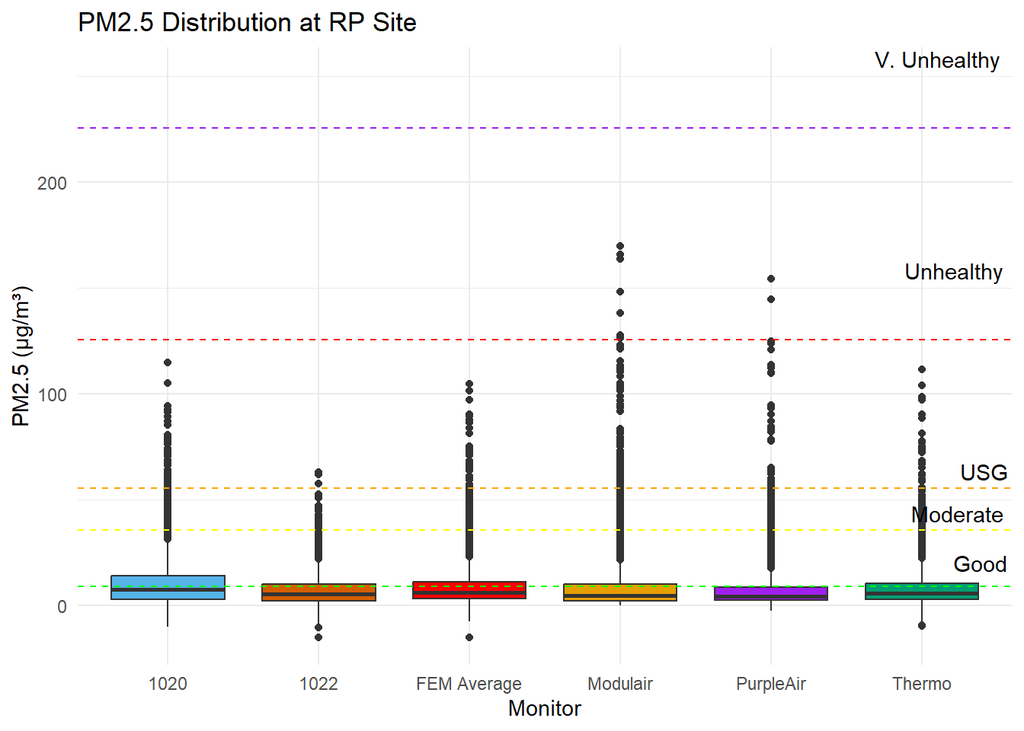

```r
# create boxplots of PM2.5 distributions by site and monitor
# uses stack_monitor_data function from function file

rp_stacked <- stack_monitor_data(rp_data, "datetime", names(rp_recode), rp_recode) # create "stacked" monitor data to invert columns and rows for plotting
ggplot(rp_stacked, aes(x = monitor, y = pm25, fill = monitor)) +
  geom_boxplot() +
  scale_fill_manual(values = monitor_colors) +
  labs(title = "PM2.5 Distribution at RP Site", x = "Monitor", y = "PM2.5 (µg/m³)") +
  geom_hline( # Add annotated line at each AQI breakpoint
    yintercept = aqi_breaks,
    color = aqi_colors,
    linetype = "dashed"
  ) +
  annotate("text", x = Inf, y = 12,
           label = "Good",
           vjust = -0.5, hjust = 1.1) +
  annotate("text", x = Inf, y = 35.4,
           label = "Moderate",
           vjust = -0.5, hjust = 1.1) +
  annotate("text", x = Inf, y = 55.4,
           label = "USG",
           vjust = -0.5, hjust = 1.1) +
  annotate("text", x = Inf, y = 150.4,
           label = "Unhealthy",
           vjust = -0.5, hjust = 1.1) +
  annotate("text", x = Inf, y = 250.4,
           label = "V. Unhealthy",
           vjust = -0.5, hjust = 1.1) +
  theme_minimal() +
  theme(legend.position = "none")
```

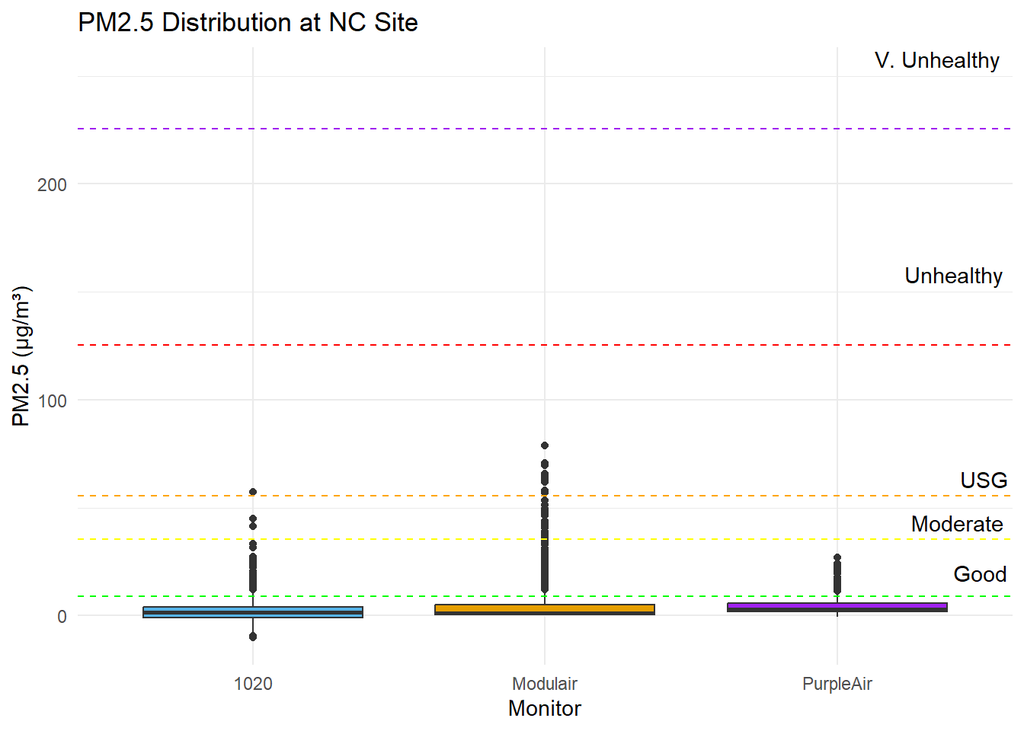

```r
nc_stacked <- stack_monitor_data(nc_data, "datetime", names(nc_recode), nc_recode)
ggplot(nc_stacked, aes(x = monitor, y = pm25, fill = monitor)) +
  geom_boxplot() +
  scale_fill_manual(values = monitor_colors) +
  labs(title = "PM2.5 Distribution at NC Site", x = "Monitor", y = "PM2.5 (µg/m³)") +
  geom_hline(
    yintercept = aqi_breaks,
    color = aqi_colors,
    linetype = "dashed"
  ) +
  annotate("text", x = Inf, y = 12,
           label = "Good",
           vjust = -0.5, hjust = 1.1) +
  annotate("text", x = Inf, y = 35.4,
           label = "Moderate",
           vjust = -0.5, hjust = 1.1) +
  annotate("text", x = Inf, y = 55.4,
           label = "USG",
           vjust = -0.5, hjust = 1.1) +
  annotate("text", x = Inf, y = 150.4,
           label = "Unhealthy",
           vjust = -0.5, hjust = 1.1) +
  annotate("text", x = Inf, y = 250.4,
           label = "V. Unhealthy",
           vjust = -0.5, hjust = 1.1) +
  theme_minimal() +
  theme(legend.position = "none")
```

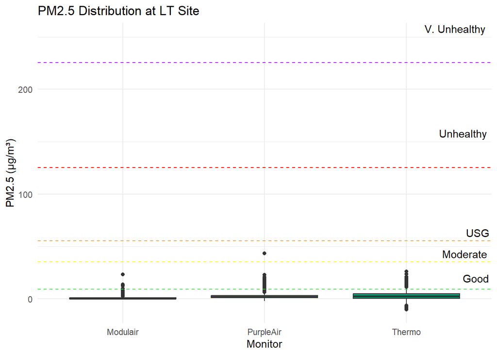

```r
lt_stacked <- stack_monitor_data(lt_data, "datetime", names(lt_recode), lt_recode)
ggplot(lt_stacked, aes(x = monitor, y = pm25, fill = monitor)) +
  geom_boxplot() +
  scale_fill_manual(values = monitor_colors) +
  labs(title = "PM2.5 Distribution at LT Site", x = "Monitor", y = "PM2.5 (µg/m³)") +
 geom_hline(
    yintercept = aqi_breaks,
    color = aqi_colors,
    linetype = "dashed"
  ) +
  annotate("text", x = Inf, y = 12,
           label = "Good",
           vjust = -0.5, hjust = 1.1) +
  annotate("text", x = Inf, y = 35.4,
           label = "Moderate",
           vjust = -0.5, hjust = 1.1) +
  annotate("text", x = Inf, y = 55.4,
           label = "USG",
           vjust = -0.5, hjust = 1.1) +
  annotate("text", x = Inf, y = 150.4,
           label = "Unhealthy",
           vjust = -0.5, hjust = 1.1) +
  annotate("text", x = Inf, y = 250.4,
           label = "V. Unhealthy",
           vjust = -0.5, hjust = 1.1) +
  theme_minimal() +
  theme(legend.position = "none")
```

## Time Series Line Graphs of 24 hour averaged PM2.5 Concentrations by Site

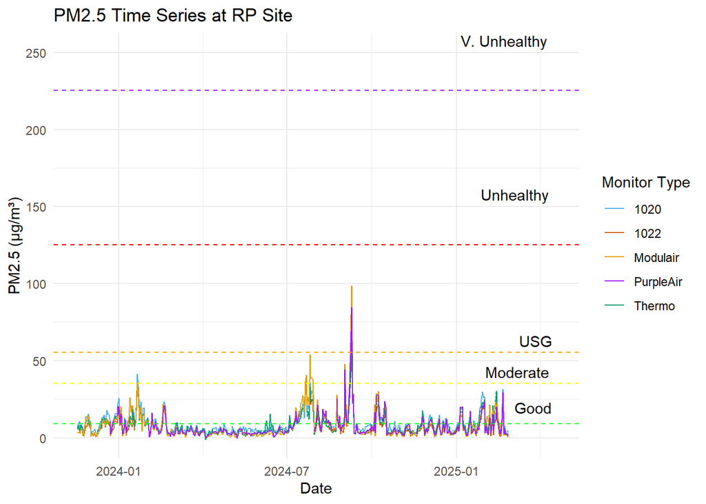

```r
final_date <- as.Date("2025-02-27")

# RP Site

ggplot(rp_daily, aes(x = date)) +
  geom_line(aes(y = rp_1020, color = "1020")) +
  geom_line(aes(y = rp_1022, color = "1022")) +
  geom_line(aes(y = rp_thermo, color = "Thermo")) +
  geom_line(aes(y = rp_modulair_pm25, color = "Modulair")) +
  geom_line(aes(y = rp_purpleair_cf1, color = "PurpleAir")) +
  # add AQI lines
  geom_hline(
    yintercept = aqi_breaks,
    color = aqi_colors,
    linetype = "dashed"
  ) +
  annotate("text", x = final_date + days(50), y = 12,     label = "Good",         vjust = -0.5, hjust = 1.1) +
  annotate("text", x = final_date + days(50), y = 35.4,   label = "Moderate",     vjust = -0.5, hjust = 1.1) +
  annotate("text", x = final_date + days(50), y = 55.4,   label = "USG",          vjust = -0.5, hjust = 1.1) +
  annotate("text", x = final_date + days(50), y = 150.4,  label = "Unhealthy",    vjust = -0.5, hjust = 1.1) +
  annotate("text", x = final_date + days(50), y = 250.4,  label = "V. Unhealthy", vjust = -0.5, hjust = 1.1) +
  scale_color_manual(values = monitor_colors) +
  labs(
    title = "PM2.5 Time Series at RP Site",
    x = "Date",
    y = "PM2.5 (µg/m³)",
    color = "Monitor Type"
  ) +
  theme_minimal()
```

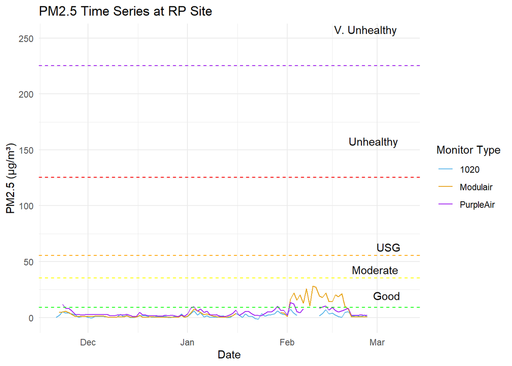

```r
# NC Site
ggplot(nc_daily, aes(x = date)) +
  geom_line(aes(y = nc_1020, color = "1020")) +
  geom_line(aes(y = nc_modulair_pm25, color = "Modulair")) +
  geom_line(aes(y = nc_purpleair_cf1, color = "PurpleAir")) +
  geom_hline(
    yintercept = aqi_breaks,
    color = aqi_colors,
    linetype = "dashed"
  ) +
  annotate("text", x = final_date + days(10), y = 12,     label = "Good",         vjust = -0.5, hjust = 1.1) +
  annotate("text", x = final_date + days(10), y = 35.4,   label = "Moderate",     vjust = -0.5, hjust = 1.1) +
  annotate("text", x = final_date + days(10), y = 55.4,   label = "USG",          vjust = -0.5, hjust = 1.1) +
  annotate("text", x = final_date + days(10), y = 150.4,  label = "Unhealthy",    vjust = -0.5, hjust = 1.1) +
  annotate("text", x = final_date + days(10), y = 250.4,  label = "V. Unhealthy", vjust = -0.5, hjust = 1.1) +
  scale_color_manual(values = monitor_colors) +
  labs(
    title = "PM2.5 Time Series at RP Site",
    x = "Date",
    y = "PM2.5 (µg/m³)",
    color = "Monitor Type"
  ) +
  theme_minimal()
```

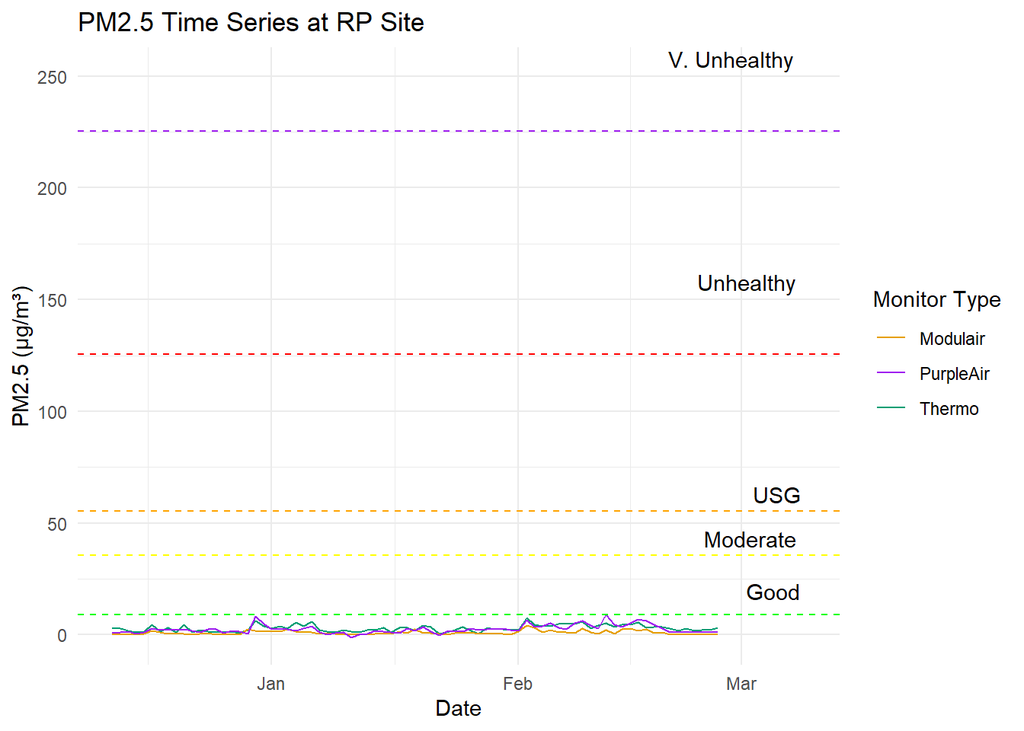

```r
# LT Site
ggplot(lt_daily, aes(x = date)) +
  geom_line(aes(y = lt_thermo, color = "Thermo")) +
  geom_line(aes(y = lt_modulair_pm25, color = "Modulair")) +
  geom_line(aes(y = lt_purpleair_cf1, color = "PurpleAir")) +
  geom_hline(
    yintercept = aqi_breaks,
    color = aqi_colors,
    linetype = "dashed"
  ) +
  annotate("text", x = final_date + days(10), y = 12,     label = "Good",         vjust = -0.5, hjust = 1.1) +
  annotate("text", x = final_date + days(10), y = 35.4,   label = "Moderate",     vjust = -0.5, hjust = 1.1) +
  annotate("text", x = final_date + days(10), y = 55.4,   label = "USG",          vjust = -0.5, hjust = 1.1) +
  annotate("text", x = final_date + days(10), y = 150.4,  label = "Unhealthy",    vjust = -0.5, hjust = 1.1) +
  annotate("text", x = final_date + days(10), y = 250.4,  label = "V. Unhealthy", vjust = -0.5, hjust = 1.1) +
  scale_color_manual(values = monitor_colors) +
  labs(
    title = "PM2.5 Time Series at RP Site",
    x = "Date",
    y = "PM2.5 (µg/m³)",
    color = "Monitor Type"
  ) +
  theme_minimal()
```

## Scatterplot w/ Line of Best Fit & 1:1 by Site

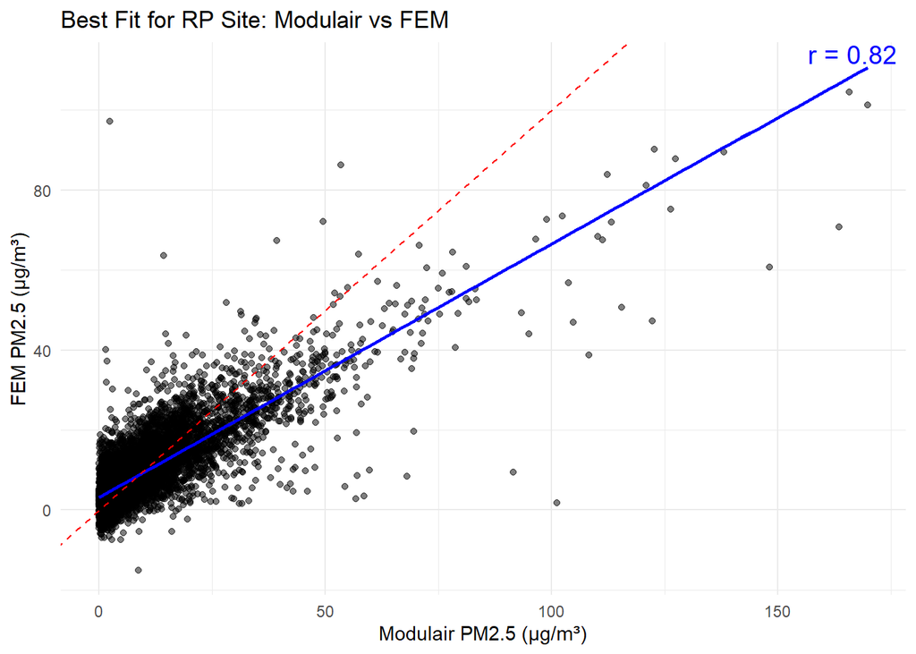

```r
plot_rp <- plot_fit(rp_data, mod_col = "rp_modulair_pm25", fem_col = "rp_fem_avg", site_label = "RP")
print(plot_rp)
```

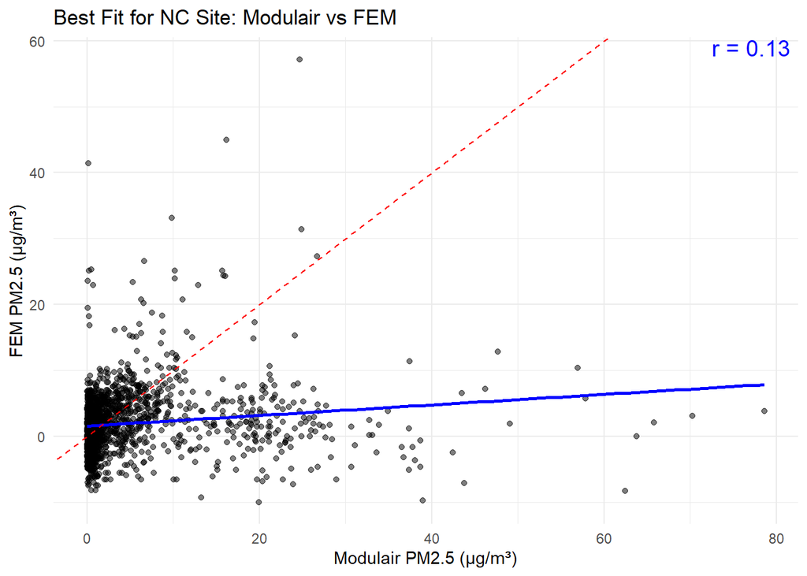

```r
plot_nc <- plot_fit(nc_data, mod_col = "nc_modulair_pm25", fem_col = "nc_1020", site_label = "NC")
print(plot_nc)
```

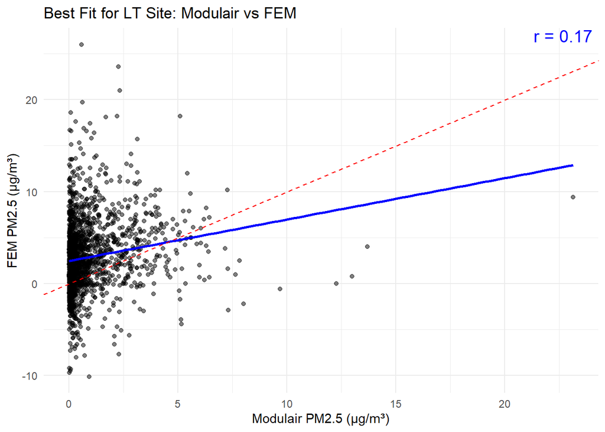

```r
plot_lt <- plot_fit(lt_data, mod_col = "lt_modulair_pm25", fem_col = "lt_thermo", site_label = "LT")
print(plot_lt)
```

## Correlation Matrix by Modeling Variable

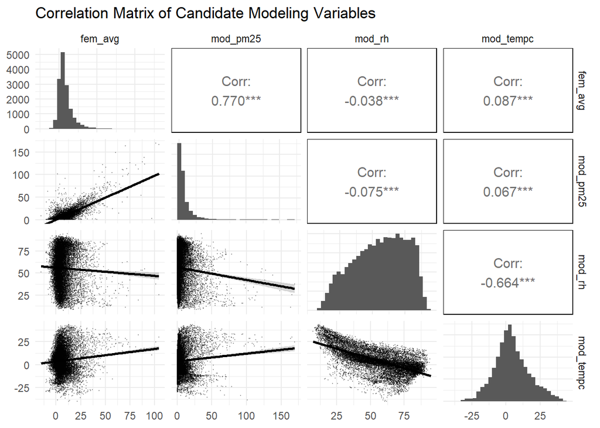

```r
# Create correlation matrix with all variables to be potentially included in modeling using combined dataset

# - fem_avg: FEM PM2.5 measurement (true value)
# - mod_pm25: Modulair PM2.5 measurement (raw)
# - mod_rh: Modulair relative humidity
# - mod_tempc: Modulair ambient temperature (°C)

model_vars <- combined_data %>%
  select(fem_avg, mod_pm25, mod_rh, mod_tempc)

# Calculate and visualize the correlation matrix using ggpairs
ggpairs(model_vars,
        lower = list(continuous = wrap("smooth", alpha = 0.3, size = 0.1)),
        upper = list(continuous = wrap("cor", size = 4)),
        diag = list(continuous = "barDiag")) +
  labs(title = "Correlation Matrix of Candidate Modeling Variables")
```

### Matrix Interpretation:

- Moderate correlation between reference and raw sensor PM2.5 (r ∼ 0.77) suggests the sensor is “in the ballpark” but needs a bias correction.
- Minimal linear correlation between PM2.5 and RH/temperature does not rule out the possibility that adding an RH or temperature term can significantly improve the final model—particularly if the sensor’s error depends on meteorology.
- Strong collinearity between temperature and humidity (r ~ −0.66) means we should be mindful about including both in a single linear regression. In some cases, one meteorological term (often RH) captures most of the sensor’s bias.

# Measures of Sensor Accuracy

## Metrics by Site & AQI Category

```r
# For Loop to calculate accuracy metrics functions for each site & overall

datasets <- list(rp = rp_data, nc = nc_data, lt = lt_data)
results <- list()

col_info <- list(
  rp = list(fem = "rp_fem_avg", mod = "rp_modulair_pm25", fem_aqi = "rp_fem_aqi", mod_aqi = "rp_modulair_aqi"),
  nc = list(fem = "nc_1020", mod = "nc_modulair_pm25", fem_aqi = "nc_fem_aqi", mod_aqi = "nc_modulair_aqi"),
  lt = list(fem = "lt_thermo", mod = "lt_modulair_pm25", fem_aqi = "lt_fem_aqi", mod_aqi = "lt_modulair_aqi")
)

for (site in names(datasets)) {
  results[[site]] <- calculate_all_metrics(
    data = datasets[[site]],
    fem_col = col_info[[site]]$fem,
    mod_col = col_info[[site]]$mod,
    fem_aqi_col = col_info[[site]]$fem_aqi,
    mod_aqi_col = col_info[[site]]$mod_aqi
  )
}

# bind tables, print results

overall_table <- bind_rows(lapply(names(results), function(site) {
  results[[site]]$overall %>% mutate(site = site)
}))
overall_table <- overall_table %>% select(site, everything())
kable(overall_table, caption = "Overall Accuracy Metrics by Site (FEM vs. Modulair)")
```

Overall Accuracy Metrics by Site (FEM vs. Modulair)

| site | R_squared | Average_Error | MAE | RMSE | NRMSE | Slope | Intercept | aqi_match_frequency |
| --- | --- | --- | --- | --- | --- | --- | --- | --- |
| rp | 0.6693856 | 0.1671611 | 3.833668 | 6.360686 | 76.95288 | 1.0571365 | -0.6394333 | 0.8240882 |
| nc | 0.0172710 | -2.3103267 | 4.926509 | 8.997140 | 475.76500 | 0.2160249 | 3.7928934 | 0.8540907 |
| lt | 0.0285074 | 1.9674870 | 3.204496 | 4.366840 | 151.66742 | 0.0633016 | 0.7294745 | 0.9383117 |

```r
for (site in names(results)) {
  print(kable(results[[site]]$stratified, caption = paste("Accuracy Metrics by AQI Category -", site, "Site")))
}
```

```
##
##
## Table: Accuracy Metrics by AQI Category - rp Site
##
## | category| Count| R_squared|      MAE| Average_Error|      RMSE|     NRMSE|
## |--------:|-----:|---------:|--------:|-------------:|---------:|---------:|
## |        1|  7548| 0.1267064|  2.55180|      0.003074|  4.077406| 103.26767|
## |        2|  3491| 0.4344228|  5.78808|      1.066931|  7.658542|  49.20491|
## |        3|   146| 0.2105666| 16.00307|     -7.972920| 20.602978|  49.36735|
## |        4|    33| 0.1551601| 35.51979|    -21.314697| 42.931711|  59.91358|
##
##
## Table: Accuracy Metrics by AQI Category - nc Site
##
## | category| Count| R_squared|       MAE| Average_Error|      RMSE|     NRMSE|
## |--------:|-----:|---------:|---------:|-------------:|---------:|---------:|
## |        1|  2126| 0.0018865|  4.685750|     -2.700175|  8.708089| 693.59344|
## |        2|    92| 0.0023834|  9.600934|      5.687960| 12.683645|  85.02589|
## |        3|     2| 1.0000000| 35.001000|     35.001000| 35.550255|  82.29226|
## |        4|     1|        NA| 32.518000|     32.518000| 32.518000|  56.84965|
##
##
## Table: Accuracy Metrics by AQI Category - lt Site
##
## | category| Count| R_squared|       MAE| Average_Error|      RMSE|     NRMSE|
## |--------:|-----:|---------:|---------:|-------------:|---------:|---------:|
## |        1|  1737| 0.0256357|  2.712692|      1.412446|  3.447728| 150.94782|
## |        2|   111| 0.0096204| 10.900559|     10.653135| 11.465824|  94.03772|
```

## Calculate Overall Accuracy Metrics

```r
# apply accuracy metrics functions to combined dataset

combined_metrics <- calculate_all_metrics(
  data = combined_data,
  fem_col = "fem_avg",
  mod_col = "mod_pm25",
  fem_aqi_col = "fem_aqi",
  mod_aqi_col = "mod_aqi"
)

# Display the overall metrics for the combined dataset
print(combined_metrics$overall)
```

```
## # A tibble: 1 × 8
##   R_squared Average_Error   MAE  RMSE NRMSE Slope Intercept aqi_match_frequency
##       <dbl>         <dbl> <dbl> <dbl> <dbl> <dbl>     <dbl>               <dbl>
## 1     0.593        0.0715  3.90  6.56  96.7 0.975    0.0979               0.842
```

```r
# Display the stratified accuracy metrics by AQI category for the combined dataset
kable(combined_metrics$stratified, caption = "Accuracy Metrics by AQI Category - Combined Data")
```

Accuracy Metrics by AQI Category - Combined Data

| category | Count | R_squared | MAE | Average_Error | RMSE | NRMSE |
| --- | --- | --- | --- | --- | --- | --- |
| 1 | 11411 | 0.0558350 | 2.931397 | -0.2248953 | 5.070934 | 158.79801 |
| 2 | 3694 | 0.4144304 | 6.022049 | 1.4531934 | 7.935956 | 51.37488 |
| 3 | 148 | 0.1942612 | 16.259795 | -7.3921914 | 20.876425 | 49.99883 |
| 4 | 34 | 0.1778051 | 35.431500 | -19.7313824 | 42.661724 | 59.89217 |

# Preliminary Conclusions from EDA and Rationale for Model Selection

Below is a high-level analytical perspective on our exploratory data analysis (EDA) across the three sites (RP, NC, and LT) and what it suggests for our model selection. This discussion focuses solely on the insights derived from the descriptive summaries, AQI distributions, correlation matrix, and raw FEM vs. Modulair performance metrics. It is meant to guide our modeling effort, which we have already initiated, but here I summarize the key takeaways.

## 1. Observed Relationships and Sensor Performance

- **RP Site:**
  - The raw correlation (R² ≈ 0.67) between the raw Modulair PM2.5 (`mod_pm25`) and the FEM average (`fem_avg`) is fairly strong for an uncorrected sensor compared to a regulatory monitor.
  - The slope is approximately 1.06 with an intercept around -0.64, suggesting that the Modulair sensor slightly overestimates at higher concentrations and slightly underestimates at lower concentrations.
  - Error metrics indicate a mean absolute error (MAE) of ~3.83 µg/m³ and a root mean square error (RMSE) of ~6.36 µg/m³. The AQI match frequency is around 82%, meaning that about 18% of the time the raw sensor value falls into a different AQI bin than the FEM.
  - Stratification by AQI category shows increasing error, especially for the “USG” (Unhealthy for Sensitive Groups) and “Unhealthy” categories, where the limited sample size in “Unhealthy” (33 observations) still reveals a significant negative bias and high error (MAE ~35.5 µg/m³).
- **NC Site:**
  - The NC site exhibits very low correlation (R² ≈ 0.017) between the sensor and FEM measurements, with a negative average error (≈ -2.31 µg/m³) and a high RMSE (~9.0 µg/m³). The extremely high normalized RMSE (NRMSE ~476%) suggests that there may be operational issues (such as the FEM BAM under-sampling) affecting the data quality here.
  - The AQI distribution is heavily skewed toward “Good” (over 95% of observations), which limits the diversity of pollution levels captured.
- **LT Site:**
  - The LT site shows an R² of only ~0.0285 with a positive average error (~1.97 µg/m³) and a lower RMSE (~4.37 µg/m³) compared to NC. The NRMSE is still high (~152%), indicating large relative error compared to the low PM2.5 levels observed.
  - AQI distribution here is again mostly in the “Good” category (~94%), with a small percentage in the “Moderate” range.

## 2. Descriptive Statistics and Correlation Insights

- At the RP site, `mod_pm25` has a mean around 8.10 µg/m³ and a maximum of about 170 µg/m³, while `fem_avg` has a mean of about 8.25 µg/m³ and a maximum of roughly 104.5 µg/m³. This indicates that while most measurements are in a similar range, there are occasional high spikes in the sensor data that are not fully reflected in the FEM.
- The RP sensor’s RH values span from ~7% to 95% (mean ~54%), and the temperature data also cover a broad range. The correlation matrix shows a modest negative correlation (r ≈ -0.66) between RH and temperature, which is expected meteorologically.
- Although the direct correlation between RH and `fem_avg` is small (r ≈ -0.038), previous studies (including those by Barkjohn et al.) indicate that even a small systematic effect of RH on sensor scattering can be leveraged to improve accuracy. This justifies the inclusion of RH as an additive or interaction term in our models.

## 4. Site Comparisons and Data Selection

Given these insights, I have decided to move forward primarily with the RP site data for model development. The RP dataset offers a robust and representative sample with sufficient variability across AQI categories to support a nuanced correction model that may incorporate nonlinear or interaction effects with RH. For future work, it might be worthwhile to explore why the NC site performs poorly and whether additional data cleaning or sensor calibration is needed there.

*This summary is based on the descriptive statistics, AQI category counts, accuracy metrics by site, and stratified performance metrics we generated during our EDA. It serves as the rationale for our current focus on the RP site for modeling, while also highlighting potential areas of improvement in model specification (e.g., nonlinear terms or interactions) to address biases observed at higher pollution levels.*